# Homework 4

FIRSTNAME LASTNAME

February 15, 2024

# Instructions

**Exercises:** 2,3 (Pg. 151); 2,4 (Pg. 156); 1,2 (Pgs. 160-161); 2 (Pg. 163); 2,3,4 (Pg. 168)

**Submission:** Submit via an electronic document on Sakai. Must be submitted as a HTML file generated in RStudio. All assigned problems are chosen according to the textbook *R for Data Science*. You do not need R code to answer every question. If you answer without using R code, delete the code chunk. If the question requires R code, make sure you display R code. If the question requires a figure, make sure you display a figure. A lot of the questions can be answered in written response, but require R code and/or figures for understanding and explaining.

# Chapter 9 (Pg. 151)

## Exercise 2

```r
table2_cases <- table2 %>%
  filter(type == 'cases') %>%
  rename(cases = count)

print(table2_cases)
```

```
## # A tibble: 6 × 4
##   country      year type   cases
##   <chr>       <dbl> <chr>  <dbl>
## 1 Afghanistan  1999 cases    745
## 2 Afghanistan  2000 cases   2666
## 3 Brazil       1999 cases  37737
## 4 Brazil       2000 cases  80488
## 5 China        1999 cases 212258
## 6 China        2000 cases 213766
```

```r
table2_populations <- filter(table2, type == 'population') %>% rename(population = count)

print(table2_populations)
```

```
## # A tibble: 6 × 4
##   country      year type       population
##   <chr>       <dbl> <chr>           <dbl>
## 1 Afghanistan  1999 population   19987071
## 2 Afghanistan  2000 population   20595360
## 3 Brazil       1999 population  172006362
## 4 Brazil       2000 population  174504898
## 5 China        1999 population 1272915272
## 6 China        2000 population 1280428583
```

```r
finaltable <- table2_cases %>% mutate(population = table2_populations$population, rate = (cases / population) * 10000)

frfinaltable <- finaltable %>%
  gather("cases", "population", "rate", key = 'type', value = 'count') %>%
  arrange(country, year, type)

print(frfinaltable)
```

```
## # A tibble: 18 × 4
##    country      year type         count
##    <chr>       <dbl> <chr>        <dbl>
##  1 Afghanistan  1999 cases      7.45e+2
##  2 Afghanistan  1999 population 2.00e+7
##  3 Afghanistan  1999 rate       3.73e-1
##  4 Afghanistan  2000 cases      2.67e+3
##  5 Afghanistan  2000 population 2.06e+7
##  6 Afghanistan  2000 rate       1.29e+0
##  7 Brazil       1999 cases      3.77e+4
##  8 Brazil       1999 population 1.72e+8
##  9 Brazil       1999 rate       2.19e+0
## 10 Brazil       2000 cases      8.05e+4
## 11 Brazil       2000 population 1.75e+8
## 12 Brazil       2000 rate       4.61e+0
## 13 China        1999 cases      2.12e+5
## 14 China        1999 population 1.27e+9
## 15 China        1999 rate       1.67e+0
## 16 China        2000 cases      2.14e+5
## 17 China        2000 population 1.28e+9
## 18 China        2000 rate       1.67e+0
```

```r
print(table4a) # cases
```

```
## # A tibble: 3 × 3
##   country     `1999` `2000`
##   <chr>        <dbl>  <dbl>
## 1 Afghanistan    745   2666
## 2 Brazil       37737  80488
## 3 China       212258 213766
```

```r
print(table4b) # populations
```

```
## # A tibble: 3 × 3
##   country         `1999`     `2000`
##   <chr>            <dbl>      <dbl>
## 1 Afghanistan   19987071   20595360
## 2 Brazil       172006362  174504898
## 3 China       1272915272 1280428583
```

```r
tabletry <- gather(table4a, '1999', '2000', key = 'year', value = 'cases')
head(tabletry)
```

```
## # A tibble: 6 × 3
##   country     year   cases
##   <chr>       <chr>  <dbl>
## 1 Afghanistan 1999     745
## 2 Brazil      1999   37737
## 3 China       1999  212258
## 4 Afghanistan 2000    2666
## 5 Brazil      2000   80488
## 6 China       2000  213766
```

```r
final4 <- gather(table4b, '1999', '2000',key = 'year', value = 'population') %>%
  mutate(cases = tabletry$cases, rate = (cases / population) * 10000) %>%
  gather('population', 'cases', 'rate', key = 'type', value = 'count') %>%
  arrange(country, year, type)

print(final4)
```

```
## # A tibble: 18 × 4
##    country     year  type         count
##    <chr>       <chr> <chr>        <dbl>
##  1 Afghanistan 1999  cases      7.45e+2
##  2 Afghanistan 1999  population 2.00e+7
##  3 Afghanistan 1999  rate       3.73e-1
##  4 Afghanistan 2000  cases      2.67e+3
##  5 Afghanistan 2000  population 2.06e+7
##  6 Afghanistan 2000  rate       1.29e+0
##  7 Brazil      1999  cases      3.77e+4
##  8 Brazil      1999  population 1.72e+8
##  9 Brazil      1999  rate       2.19e+0
## 10 Brazil      2000  cases      8.05e+4
## 11 Brazil      2000  population 1.75e+8
## 12 Brazil      2000  rate       4.61e+0
## 13 China       1999  cases      2.12e+5
## 14 China       1999  population 1.27e+9
## 15 China       1999  rate       1.67e+0
## 16 China       2000  cases      2.14e+5
## 17 China       2000  population 1.28e+9
## 18 China       2000  rate       1.67e+0
```

I feel like Table4 was easier to work with, even though it was two tables, I got way fewer errors from it. table2 having all the data mushed together was just needlessly hard to work with.

Coming back to this answer, pretty sure this isnt what you wanted, and I def had more errors with table2 because I did it first.

## Exercise 3

```r
print(table1)
```

```
## # A tibble: 6 × 4
##   country      year  cases population
##   <chr>       <dbl>  <dbl>      <dbl>
## 1 Afghanistan  1999    745   19987071
## 2 Afghanistan  2000   2666   20595360
## 3 Brazil       1999  37737  172006362
## 4 Brazil       2000  80488  174504898
## 5 China        1999 212258 1272915272
## 6 China        2000 213766 1280428583
```

```r
print(table2)
```

```
## # A tibble: 12 × 4
##    country      year type            count
##    <chr>       <dbl> <chr>           <dbl>
##  1 Afghanistan  1999 cases             745
##  2 Afghanistan  1999 population   19987071
##  3 Afghanistan  2000 cases            2666
##  4 Afghanistan  2000 population   20595360
##  5 Brazil       1999 cases           37737
##  6 Brazil       1999 population  172006362
##  7 Brazil       2000 cases           80488
##  8 Brazil       2000 population  174504898
##  9 China        1999 cases          212258
## 10 China        1999 population 1272915272
## 11 China        2000 cases          213766
## 12 China        2000 population 1280428583
```

```r
fixedup <- spread(table2, key = 'type', value = 'count')
print(fixedup)
```

```
## # A tibble: 6 × 4
##   country      year  cases population
##   <chr>       <dbl>  <dbl>      <dbl>
## 1 Afghanistan  1999    745   19987071
## 2 Afghanistan  2000   2666   20595360
## 3 Brazil       1999  37737  172006362
## 4 Brazil       2000  80488  174504898
## 5 China        1999 212258 1272915272
## 6 China        2000 213766 1280428583
```

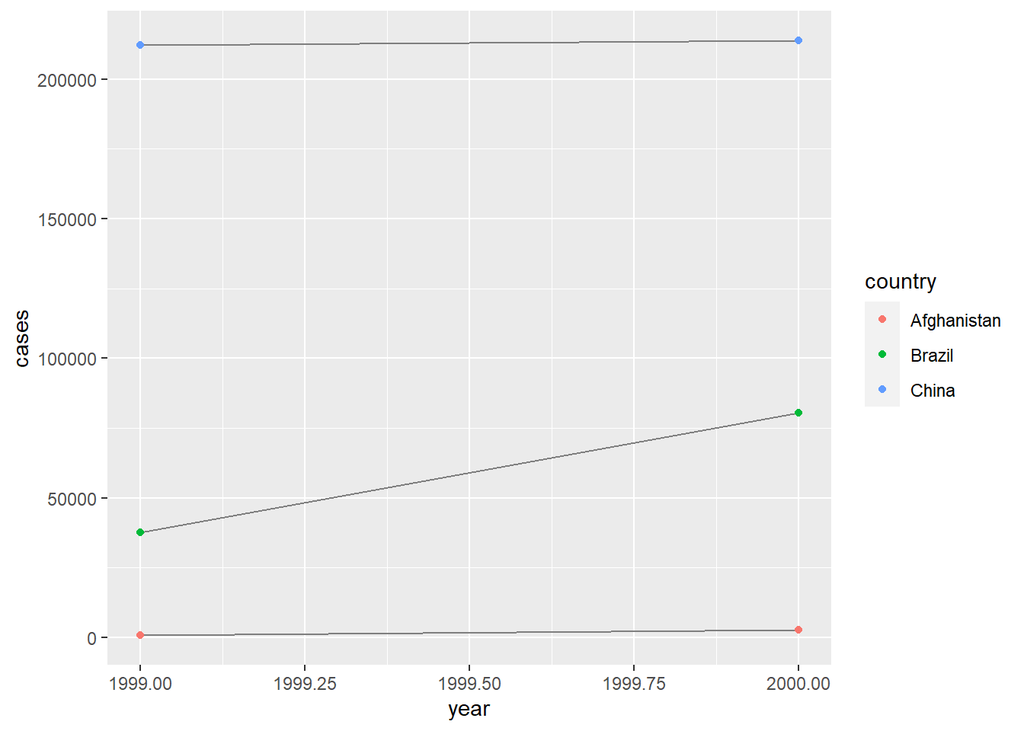

```r
library(ggplot2)
ggplot(fixedup, aes(year, cases)) +  geom_line(aes(group = country), color = "grey50") +  geom_point(aes(color = country))
```

# Chapter 9 (Pg. 156)

## Exercise 2

```r
#table4a %>%  gather(1999, 2000, key = "year", value = "cases")
table4a %>%  gather('1999', '2000', key = "year", value = "cases")
```

```
## # A tibble: 6 × 3
##   country     year   cases
##   <chr>       <chr>  <dbl>
## 1 Afghanistan 1999     745
## 2 Brazil      1999   37737
## 3 China       1999  212258
## 4 Afghanistan 2000    2666
## 5 Brazil      2000   80488
## 6 China       2000  213766
```

```
#> Error in eval(expr, envir, enclos): #> Position must be between 0 and n
```

The code fails because the columns in gather need to be inside ’’ marks. You cant just put in the column name raw. RStudio is reading 1999 and 2000 as numbers in the first line.

## Exercise 4

```r
preg <- tribble(  ~pregnant, ~male, ~female,  "yes",     NA,    10,  "no",      20,    12 )
print(preg)
```

```
## # A tibble: 2 × 3
##   pregnant  male female
##   <chr>    <dbl>  <dbl>
## 1 yes         NA     10
## 2 no          20     12
```

```r
#ppreg <- spread(preg, key = "pregnant", value = 'female'', value = 'male'') %>%
#  rename(female_not_preg = no, female_preg = yes) #%>%
  #spread(preg, key = "male", value = 'male') %>%
  #rename(female_not_preg = no, female_preg = yes)

preg_tidy <- preg %>%
  gather(key = "gender", value = "count", -pregnant)
print(preg_tidy)
```

```
## # A tibble: 4 × 3
##   pregnant gender count
##   <chr>    <chr>  <dbl>
## 1 yes      male      NA
## 2 no       male      20
## 3 yes      female    10
## 4 no       female    12
```

I tidyed it with a gather, collecting the male and female columns into just one gender column that hold the counts next to it.

# Chapter 9 (Pgs. 160-161)

## Exercise 1

```r
tibble(x = c("a,b,c", "d,e,f,g", "h,i,j")) %>%  separate(x, c("one", "two", "three"), extra = "merge")
```

```
## # A tibble: 3 × 3
##   one   two   three
##   <chr> <chr> <chr>
## 1 a     b     c
## 2 d     e     f,g
## 3 h     i     j
```

```r
tibble(x = c("a,b,c", "d,e", "f,g,i")) %>%  separate(x, c("one", "two", "three"), fill = "left")
```

```
## # A tibble: 3 × 3
##   one   two   three
##   <chr> <chr> <chr>
## 1 a     b     c
## 2 <NA>  d     e
## 3 f     g     i
```

For unite if remove=false, the united columns will remain in the tibble with the newly combined one. Similarly, in seperate, if remove = false: the column you just split will remain in its unaltered form, with the split columns added in addition.

# Chapter 9 (Pg. 163)

## Exercise 2

Direction in fill lets you do what fill above does, but for vertical movement too. So you can push all values down to the bottom or pull them up. Think of it like tetris, where things fall as long as there is nothing beneath them.

# Chapter 9 (Pg. 168)

## Exercise 2

```r
print(who)
```

```
## # A tibble: 7,240 × 60
##    country  iso2  iso3   year new_sp_m014 new_sp_m1524 new_sp_m2534 new_sp_m3544
##    <chr>    <chr> <chr> <dbl>       <dbl>        <dbl>        <dbl>        <dbl>
##  1 Afghani… AF    AFG    1980          NA           NA           NA           NA
##  2 Afghani… AF    AFG    1981          NA           NA           NA           NA
##  3 Afghani… AF    AFG    1982          NA           NA           NA           NA
##  4 Afghani… AF    AFG    1983          NA           NA           NA           NA
##  5 Afghani… AF    AFG    1984          NA           NA           NA           NA
##  6 Afghani… AF    AFG    1985          NA           NA           NA           NA
##  7 Afghani… AF    AFG    1986          NA           NA           NA           NA
##  8 Afghani… AF    AFG    1987          NA           NA           NA           NA
##  9 Afghani… AF    AFG    1988          NA           NA           NA           NA
## 10 Afghani… AF    AFG    1989          NA           NA           NA           NA
## # ℹ 7,230 more rows
## # ℹ 52 more variables: new_sp_m4554 <dbl>, new_sp_m5564 <dbl>,
## #   new_sp_m65 <dbl>, new_sp_f014 <dbl>, new_sp_f1524 <dbl>,
## #   new_sp_f2534 <dbl>, new_sp_f3544 <dbl>, new_sp_f4554 <dbl>,
## #   new_sp_f5564 <dbl>, new_sp_f65 <dbl>, new_sn_m014 <dbl>,
## #   new_sn_m1524 <dbl>, new_sn_m2534 <dbl>, new_sn_m3544 <dbl>,
## #   new_sn_m4554 <dbl>, new_sn_m5564 <dbl>, new_sn_m65 <dbl>, …
```

```r
tiddywho <- who %>%  gather(code, value, new_sp_m014:newrel_f65, na.rm = TRUE) %>%
  #mutate(    code = stringr::str_replace(code, "newrel", "new_rel")  ) %>%
  separate(code, c("new", "var", "sexage")) %>%  select(-new, -iso2, -iso3) %>%
  separate(sexage, c("sex", "age"), sep = 1)
print(tiddywho)
```

```
## # A tibble: 76,046 × 6
##    country      year var   sex   age   value
##    <chr>       <dbl> <chr> <chr> <chr> <dbl>
##  1 Afghanistan  1997 sp    m     014       0
##  2 Afghanistan  1998 sp    m     014      30
##  3 Afghanistan  1999 sp    m     014       8
##  4 Afghanistan  2000 sp    m     014      52
##  5 Afghanistan  2001 sp    m     014     129
##  6 Afghanistan  2002 sp    m     014      90
##  7 Afghanistan  2003 sp    m     014     127
##  8 Afghanistan  2004 sp    m     014     139
##  9 Afghanistan  2005 sp    m     014     151
## 10 Afghanistan  2006 sp    m     014     193
## # ℹ 76,036 more rows
```

## Exercise 3

```r
print(who)
```

```
## # A tibble: 7,240 × 60
##    country  iso2  iso3   year new_sp_m014 new_sp_m1524 new_sp_m2534 new_sp_m3544
##    <chr>    <chr> <chr> <dbl>       <dbl>        <dbl>        <dbl>        <dbl>
##  1 Afghani… AF    AFG    1980          NA           NA           NA           NA
##  2 Afghani… AF    AFG    1981          NA           NA           NA           NA
##  3 Afghani… AF    AFG    1982          NA           NA           NA           NA
##  4 Afghani… AF    AFG    1983          NA           NA           NA           NA
##  5 Afghani… AF    AFG    1984          NA           NA           NA           NA
##  6 Afghani… AF    AFG    1985          NA           NA           NA           NA
##  7 Afghani… AF    AFG    1986          NA           NA           NA           NA
##  8 Afghani… AF    AFG    1987          NA           NA           NA           NA
##  9 Afghani… AF    AFG    1988          NA           NA           NA           NA
## 10 Afghani… AF    AFG    1989          NA           NA           NA           NA
## # ℹ 7,230 more rows
## # ℹ 52 more variables: new_sp_m4554 <dbl>, new_sp_m5564 <dbl>,
## #   new_sp_m65 <dbl>, new_sp_f014 <dbl>, new_sp_f1524 <dbl>,
## #   new_sp_f2534 <dbl>, new_sp_f3544 <dbl>, new_sp_f4554 <dbl>,
## #   new_sp_f5564 <dbl>, new_sp_f65 <dbl>, new_sn_m014 <dbl>,
## #   new_sn_m1524 <dbl>, new_sn_m2534 <dbl>, new_sn_m3544 <dbl>,
## #   new_sn_m4554 <dbl>, new_sn_m5564 <dbl>, new_sn_m65 <dbl>, …
```

```r
unique_mapping <- who %>%
  group_by(iso2, iso3) %>%
  summarise(n_distinct_countries = n_distinct(country), .groups = 'drop') %>%
  ungroup()
print(unique_mapping)
```

```
## # A tibble: 219 × 3
##    iso2  iso3  n_distinct_countries
##    <chr> <chr>                <int>
##  1 AD    AND                      1
##  2 AE    ARE                      1
##  3 AF    AFG                      1
##  4 AG    ATG                      1
##  5 AI    AIA                      1
##  6 AL    ALB                      1
##  7 AM    ARM                      1
##  8 AN    ANT                      1
##  9 AO    AGO                      1
## 10 AR    ARG                      1
## # ℹ 209 more rows
```

```r
max_val <- max(unique_mapping$n_distinct_countries)
print(max_val)
```

```
## [1] 1
```

You can see that the max value of distince contries for every iso2 and iso3 is 1. That means that they are directly coorelated to the country. They are one-to-one and completely redundant.

## Exercise 4

```r
print(tiddywho)
```

```
## # A tibble: 76,046 × 6
##    country      year var   sex   age   value
##    <chr>       <dbl> <chr> <chr> <chr> <dbl>
##  1 Afghanistan  1997 sp    m     014       0
##  2 Afghanistan  1998 sp    m     014      30
##  3 Afghanistan  1999 sp    m     014       8
##  4 Afghanistan  2000 sp    m     014      52
##  5 Afghanistan  2001 sp    m     014     129
##  6 Afghanistan  2002 sp    m     014      90
##  7 Afghanistan  2003 sp    m     014     127
##  8 Afghanistan  2004 sp    m     014     139
##  9 Afghanistan  2005 sp    m     014     151
## 10 Afghanistan  2006 sp    m     014     193
## # ℹ 76,036 more rows
```

```r
total_tb <- tiddywho %>%
  group_by(country, year, sex) %>%
  summarise(total_cases = sum(value, na.rm = TRUE), .groups = "drop") %>%
  ungroup()

print(total_tb)
```

```
## # A tibble: 6,729 × 4
##    country      year sex   total_cases
##    <chr>       <dbl> <chr>       <dbl>
##  1 Afghanistan  1997 f             102
##  2 Afghanistan  1997 m              26
##  3 Afghanistan  1998 f            1207
##  4 Afghanistan  1998 m             571
##  5 Afghanistan  1999 f             517
##  6 Afghanistan  1999 m             228
##  7 Afghanistan  2000 f            1751
##  8 Afghanistan  2000 m             915
##  9 Afghanistan  2001 f            3062
## 10 Afghanistan  2001 m            1577
## # ℹ 6,719 more rows
```

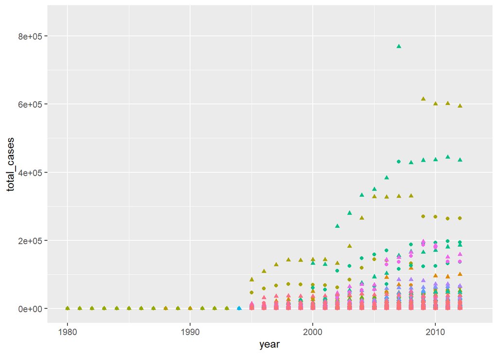

```r
# If i include the legend it takes up so much space you cant see the visualization.
ggplot(total_tb, aes(x = year, y=total_cases, color = country, shape = sex)) + geom_point() + theme(legend.position = "none")
```

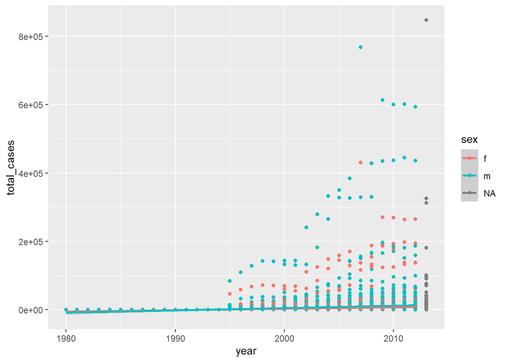

```r
#country is the issue bc there are so many unique values so I offer this
ggplot(total_tb, aes(x = year, y=total_cases, color = sex)) + geom_point() +
  geom_smooth(method = "lm")
```

```r
#bc does the country reaaaaaly matter?
```